# Assignment_1

2024-10-22

Group 3: Julian Janisch, Hanka Jankovicova, Livia Miclaus, Sofiia Selimova, Bence Zsolt Vízvári

## 1. Task

In this task the data is read into R. We take a first look at the structure of the data, check for missing data, and remove irrelevant variables while converting categorical data into factors.

Now we can read in the data into a variable called airbnb:

```r
airbnb <- read.csv("airbnb.csv", sep =",", header = TRUE)
```

Now we can take a closer look at the structure of the data:

```r
glimpse(airbnb)
```

```
## Rows: 3,537
## Columns: 21
## $ X                          <int> 0, 1, 2, 3, 4, 5, 6, 7, 8, 9, 10, 11, 12, 1…
## $ realSum                    <dbl> 250.5668, 156.6043, 283.0564, 301.7554, 150…
## $ room_type                  <chr> "Entire home/apt", "Entire home/apt", "Enti…
## $ room_shared                <int> 0, 0, 0, 0, 0, 0, 0, 0, 0, 0, 0, 0, 0, 0, 0…
## $ room_private               <int> 0, 0, 0, 0, 0, 1, 0, 1, 0, 0, 0, 0, 0, 0, 0…
## $ person_capacity            <int> 3, 3, 5, 4, 2, 2, 3, 2, 4, 2, 2, 2, 2, 2, 4…
## $ host_is_superhost          <int> 1, 0, 1, 1, 1, 1, 1, 0, 1, 1, 1, 0, 0, 0, 0…
## $ multi                      <int> 1, 0, 0, 0, 0, 1, 0, 0, 0, 1, 1, 0, 0, 0, 0…
## $ biz                        <int> 0, 0, 1, 1, 1, 0, 1, 0, 1, 0, 0, 1, 1, 1, 1…
## $ cleanliness_rating         <int> 10, 10, 10, 10, 10, 10, 9, 8, 9, 10, 10, 9,…
## $ guest_satisfaction_overall <int> 99, 97, 95, 94, 96, 99, 91, 92, 86, 97, 97,…
## $ bedrooms                   <int> 1, 1, 2, 2, 1, 1, 1, 1, 1, 1, 1, 1, 1, 1, 1…
## $ dist                       <dbl> 1.732893, 4.807912, 2.811773, 3.240595, 2.2…
## $ metro_dist                 <dbl> 0.2126271, 0.2282531, 0.2441629, 0.6104299,…
## $ attr_index                 <dbl> 118.64683, 80.14502, 101.24811, 92.47394, 1…
## $ attr_index_norm            <dbl> 8.496979, 5.739643, 7.250957, 6.622588, 8.8…
## $ rest_index                 <dbl> 185.09672, 85.72760, 151.36429, 129.86383, …
## $ rest_index_norm            <dbl> 4.424871, 2.049380, 3.618473, 3.104489, 3.6…
## $ lng                        <dbl> 16.36500, 16.33356, 16.33600, 16.33006, 16.…
## $ lat                        <dbl> 48.22300, 48.17459, 48.21100, 48.20921, 48.…
## $ weekend                    <int> 0, 0, 0, 0, 0, 0, 0, 0, 0, 0, 0, 0, 0, 0, 0…
```

```r
str(airbnb)
```

```
## 'data.frame':    3537 obs. of  21 variables:
##  $ X                         : int  0 1 2 3 4 5 6 7 8 9 ...
##  $ realSum                   : num  251 157 283 302 151 ...
##  $ room_type                 : chr  "Entire home/apt" "Entire home/apt" "Entire home/apt" "Entire home/apt" ...
##  $ room_shared               : int  0 0 0 0 0 0 0 0 0 0 ...
##  $ room_private              : int  0 0 0 0 0 1 0 1 0 0 ...
##  $ person_capacity           : int  3 3 5 4 2 2 3 2 4 2 ...
##  $ host_is_superhost         : int  1 0 1 1 1 1 1 0 1 1 ...
##  $ multi                     : int  1 0 0 0 0 1 0 0 0 1 ...
##  $ biz                       : int  0 0 1 1 1 0 1 0 1 0 ...
##  $ cleanliness_rating        : int  10 10 10 10 10 10 9 8 9 10 ...
##  $ guest_satisfaction_overall: int  99 97 95 94 96 99 91 92 86 97 ...
##  $ bedrooms                  : int  1 1 2 2 1 1 1 1 1 1 ...
##  $ dist                      : num  1.73 4.81 2.81 3.24 2.24 ...
##  $ metro_dist                : num  0.213 0.228 0.244 0.61 1.12 ...
##  $ attr_index                : num  118.6 80.1 101.2 92.5 124.3 ...
##  $ attr_index_norm           : num  8.5 5.74 7.25 6.62 8.9 ...
##  $ rest_index                : num  185.1 85.7 151.4 129.9 154.3 ...
##  $ rest_index_norm           : num  4.42 2.05 3.62 3.1 3.69 ...
##  $ lng                       : num  16.4 16.3 16.3 16.3 16.4 ...
##  $ lat                       : num  48.2 48.2 48.2 48.2 48.2 ...
##  $ weekend                   : int  0 0 0 0 0 0 0 0 0 0 ...
```

As we can see, there are 21 columns with a total of 3537 rows in our data set. Now we check if there is any data missing:

```r
colSums(is.na(airbnb))
```

```
##                          X                    realSum
##                          0                          0
##                  room_type                room_shared
##                          0                          0
##               room_private            person_capacity
##                          0                          0
##          host_is_superhost                      multi
##                          0                          0
##                        biz         cleanliness_rating
##                          0                          0
## guest_satisfaction_overall                   bedrooms
##                          0                          0
##                       dist                 metro_dist
##                          0                          0
##                 attr_index            attr_index_norm
##                          0                          0
##                 rest_index            rest_index_norm
##                          0                          0
##                        lng                        lat
##                          0                          0
##                    weekend
##                          0
```

We can see that every column displays the number 0, indicating that there is no data missing. Now let us confirm the names of the columns and remove irrelevant variables:

```r
names(airbnb)
```

```
##  [1] "X"                          "realSum"
##  [3] "room_type"                  "room_shared"
##  [5] "room_private"               "person_capacity"
##  [7] "host_is_superhost"          "multi"
##  [9] "biz"                        "cleanliness_rating"
## [11] "guest_satisfaction_overall" "bedrooms"
## [13] "dist"                       "metro_dist"
## [15] "attr_index"                 "attr_index_norm"
## [17] "rest_index"                 "rest_index_norm"
## [19] "lng"                        "lat"
## [21] "weekend"
```

```r
airbnb <- airbnb[,-c(1, 4, 5, 15, 17)]
```

We removed the variables X, room_shared, room_private, attr_index, rest_index, because we don’t need to know the record number in the table that is held in variable X. Variables room_shared and room_private are summarized in variable room_type. Value from variable attr_index is also held in variable attr_index_norm and normalized value is better for comparing the values then the absolute one. The same applies to rest_index.  
Let us now convert all the categorical variables into factors:

```r
airbnb$room_type <- as.factor(airbnb$room_type)
airbnb$host_is_superhost <- as.factor(airbnb$host_is_superhost)
airbnb$weekend <- as.factor(airbnb$weekend)
airbnb$biz <- as.factor(airbnb$biz)
airbnb$multi <- as.factor(airbnb$multi)
str(airbnb) #Check if the conversion worked well
```

```
## 'data.frame':    3537 obs. of  16 variables:
##  $ realSum                   : num  251 157 283 302 151 ...
##  $ room_type                 : Factor w/ 3 levels "Entire home/apt",..: 1 1 1 1 1 2 1 2 1 1 ...
##  $ person_capacity           : int  3 3 5 4 2 2 3 2 4 2 ...
##  $ host_is_superhost         : Factor w/ 2 levels "0","1": 2 1 2 2 2 2 2 1 2 2 ...
##  $ multi                     : Factor w/ 2 levels "0","1": 2 1 1 1 1 2 1 1 1 2 ...
##  $ biz                       : Factor w/ 2 levels "0","1": 1 1 2 2 2 1 2 1 2 1 ...
##  $ cleanliness_rating        : int  10 10 10 10 10 10 9 8 9 10 ...
##  $ guest_satisfaction_overall: int  99 97 95 94 96 99 91 92 86 97 ...
##  $ bedrooms                  : int  1 1 2 2 1 1 1 1 1 1 ...
##  $ dist                      : num  1.73 4.81 2.81 3.24 2.24 ...
##  $ metro_dist                : num  0.213 0.228 0.244 0.61 1.12 ...
##  $ attr_index_norm           : num  8.5 5.74 7.25 6.62 8.9 ...
##  $ rest_index_norm           : num  4.42 2.05 3.62 3.1 3.69 ...
##  $ lng                       : num  16.4 16.3 16.3 16.3 16.4 ...
##  $ lat                       : num  48.2 48.2 48.2 48.2 48.2 ...
##  $ weekend                   : Factor w/ 2 levels "0","1": 1 1 1 1 1 1 1 1 1 1 ...
```

## 2. Task

In this task we perform descriptive statistics on the trimmed data set and visualize the data.

```r
summary(airbnb)
```

```
##     realSum                   room_type    person_capacity host_is_superhost
##  Min.   :   63.58   Entire home/apt:2747   Min.   :2.00    0:2532
##  1st Qu.:  162.45   Private room   : 774   1st Qu.:2.00    1:1005
##  Median :  208.49   Shared room    :  16   Median :3.00
##  Mean   :  241.58                          Mean   :3.35
##  3rd Qu.:  273.47                          3rd Qu.:4.00
##  Max.   :13664.31                          Max.   :6.00
##  multi    biz      cleanliness_rating guest_satisfaction_overall
##  0:2550   0:2335   Min.   : 2.000     Min.   : 20.00
##  1: 987   1:1202   1st Qu.: 9.000     1st Qu.: 91.00
##                    Median :10.000     Median : 96.00
##                    Mean   : 9.472     Mean   : 93.73
##                    3rd Qu.:10.000     3rd Qu.: 99.00
##                    Max.   :10.000     Max.   :100.00
##     bedrooms          dist            metro_dist       attr_index_norm
##  Min.   :0.000   Min.   : 0.03981   Min.   :0.008362   Min.   :  1.388
##  1st Qu.:1.000   1st Qu.: 1.88436   1st Qu.:0.242436   1st Qu.:  5.785
##  Median :1.000   Median : 2.76014   Median :0.376317   Median :  7.449
##  Mean   :1.102   Mean   : 3.13949   Mean   :0.526670   Mean   :  8.762
##  3rd Qu.:1.000   3rd Qu.: 3.93666   3rd Qu.:0.621229   3rd Qu.:  9.865
##  Max.   :4.000   Max.   :13.33967   Max.   :5.238383   Max.   :100.000
##  rest_index_norm         lng             lat        weekend
##  Min.   :  0.6407   Min.   :16.21   Min.   :48.13   0:1738
##  1st Qu.:  2.4707   1st Qu.:16.34   1st Qu.:48.19   1:1799
##  Median :  3.4331   Median :16.36   Median :48.20
##  Mean   :  4.2396   Mean   :16.36   Mean   :48.20
##  3rd Qu.:  5.0872   3rd Qu.:16.38   3rd Qu.:48.22
##  Max.   :100.0000   Max.   :16.55   Max.   :48.29
```

```r
str(airbnb)
```

```
## 'data.frame':    3537 obs. of  16 variables:
##  $ realSum                   : num  251 157 283 302 151 ...
##  $ room_type                 : Factor w/ 3 levels "Entire home/apt",..: 1 1 1 1 1 2 1 2 1 1 ...
##  $ person_capacity           : int  3 3 5 4 2 2 3 2 4 2 ...
##  $ host_is_superhost         : Factor w/ 2 levels "0","1": 2 1 2 2 2 2 2 1 2 2 ...
##  $ multi                     : Factor w/ 2 levels "0","1": 2 1 1 1 1 2 1 1 1 2 ...
##  $ biz                       : Factor w/ 2 levels "0","1": 1 1 2 2 2 1 2 1 2 1 ...
##  $ cleanliness_rating        : int  10 10 10 10 10 10 9 8 9 10 ...
##  $ guest_satisfaction_overall: int  99 97 95 94 96 99 91 92 86 97 ...
##  $ bedrooms                  : int  1 1 2 2 1 1 1 1 1 1 ...
##  $ dist                      : num  1.73 4.81 2.81 3.24 2.24 ...
##  $ metro_dist                : num  0.213 0.228 0.244 0.61 1.12 ...
##  $ attr_index_norm           : num  8.5 5.74 7.25 6.62 8.9 ...
##  $ rest_index_norm           : num  4.42 2.05 3.62 3.1 3.69 ...
##  $ lng                       : num  16.4 16.3 16.3 16.3 16.4 ...
##  $ lat                       : num  48.2 48.2 48.2 48.2 48.2 ...
##  $ weekend                   : Factor w/ 2 levels "0","1": 1 1 1 1 1 1 1 1 1 1 ...
```

Now we check which columns are numeric:

```r
numeric_check <- sapply(airbnb, is.numeric)
```

Print the result to see TRUE/FALSE for each column…

```r
print(numeric_check)
```

```
##                    realSum                  room_type
##                       TRUE                      FALSE
##            person_capacity          host_is_superhost
##                       TRUE                      FALSE
##                      multi                        biz
##                      FALSE                      FALSE
##         cleanliness_rating guest_satisfaction_overall
##                       TRUE                       TRUE
##                   bedrooms                       dist
##                       TRUE                       TRUE
##                 metro_dist            attr_index_norm
##                       TRUE                       TRUE
##            rest_index_norm                        lng
##                       TRUE                       TRUE
##                        lat                    weekend
##                       TRUE                      FALSE
```

…and select only numeric columns from the dataset

```r
numeric_columns <- airbnb[sapply(airbnb, is.numeric)]
```

Print the first few rows of the numeric columns to verify

```r
head(numeric_columns)
```

```
##    realSum person_capacity cleanliness_rating guest_satisfaction_overall
## 1 250.5668               3                 10                         99
## 2 156.6043               3                 10                         97
## 3 283.0564               5                 10                         95
## 4 301.7554               4                 10                         94
## 5 150.7608               2                 10                         96
## 6 162.4477               2                 10                         99
##   bedrooms     dist metro_dist attr_index_norm rest_index_norm      lng
## 1        1 1.732893  0.2126271        8.496979        4.424871 16.36500
## 2        1 4.807912  0.2282531        5.739643        2.049380 16.33356
## 3        2 2.811773  0.2441629        7.250957        3.618473 16.33600
## 4        2 3.240595  0.6104299        6.622588        3.104489 16.33006
## 5        1 2.241146  1.1195067        8.898738        3.689824 16.38867
## 6        1 4.611961  0.1999263        3.729599        1.805254 16.39755
##        lat
## 1 48.22300
## 2 48.17459
## 3 48.21100
## 4 48.20921
## 5 48.19104
## 6 48.24682
```

Now we calculate the correlation matrix for the numeric columns

```r
numeric_corellation <- cor(numeric_columns)
```

Print and view the correlation matrix

```r
numeric_corellation
```

```
##                                 realSum person_capacity cleanliness_rating
## realSum                     1.000000000     0.103714570      -0.0037424775
## person_capacity             0.103714570     1.000000000      -0.0232950846
## cleanliness_rating         -0.003742478    -0.023295085       1.0000000000
## guest_satisfaction_overall -0.004864320    -0.096461160       0.6263823726
## bedrooms                    0.080097131     0.509397257      -0.0005600465
## dist                       -0.082816901    -0.008608413      -0.0221998347
## metro_dist                 -0.041710743    -0.017294194       0.0103208656
## attr_index_norm             0.070861060    -0.009511775       0.0606377110
## rest_index_norm             0.070249700    -0.005979327       0.0525121393
## lng                         0.015180320     0.017232388       0.0320860207
## lat                         0.020041644    -0.010414612       0.0054079542
##                            guest_satisfaction_overall      bedrooms
## realSum                                   -0.00486432  0.0800971314
## person_capacity                           -0.09646116  0.5093972572
## cleanliness_rating                         0.62638237 -0.0005600465
## guest_satisfaction_overall                 1.00000000  0.0232809126
## bedrooms                                   0.02328091  1.0000000000
## dist                                       0.01616636  0.0744612092
## metro_dist                                 0.03405802  0.0779067363
## attr_index_norm                            0.03409541 -0.0418414840
## rest_index_norm                            0.02441526 -0.0185046557
## lng                                        0.01228991 -0.0115466994
## lat                                        0.02456651 -0.0323029049
##                                    dist  metro_dist attr_index_norm
## realSum                    -0.082816901 -0.04171074     0.070861060
## person_capacity            -0.008608413 -0.01729419    -0.009511775
## cleanliness_rating         -0.022199835  0.01032087     0.060637711
## guest_satisfaction_overall  0.016166356  0.03405802     0.034095415
## bedrooms                    0.074461209  0.07790674    -0.041841484
## dist                        1.000000000  0.57615300    -0.590220458
## metro_dist                  0.576153000  1.00000000    -0.299652326
## attr_index_norm            -0.590220458 -0.29965233     1.000000000
## rest_index_norm            -0.567622848 -0.26859424     0.877996356
## lng                        -0.072121238 -0.10087267     0.023458474
## lat                        -0.144522633  0.02759524    -0.001451541
##                            rest_index_norm         lng          lat
## realSum                        0.070249700  0.01518032  0.020041644
## person_capacity               -0.005979327  0.01723239 -0.010414612
## cleanliness_rating             0.052512139  0.03208602  0.005407954
## guest_satisfaction_overall     0.024415259  0.01228991  0.024566511
## bedrooms                      -0.018504656 -0.01154670 -0.032302905
## dist                          -0.567622848 -0.07212124 -0.144522633
## metro_dist                    -0.268594241 -0.10087267  0.027595240
## attr_index_norm                0.877996356  0.02345847 -0.001451541
## rest_index_norm                1.000000000  0.06999206  0.060590819
## lng                            0.069992063  1.00000000  0.229389861
## lat                            0.060590819  0.22938986  1.000000000
```

```r
View(numeric_corellation)
```

Now we extract correlations of ‘realSum’ with other variables

```r
realSum_cor <- numeric_corellation[, "realSum"]
print(realSum_cor)
```

```
##                    realSum            person_capacity
##                1.000000000                0.103714570
##         cleanliness_rating guest_satisfaction_overall
##               -0.003742478               -0.004864320
##                   bedrooms                       dist
##                0.080097131               -0.082816901
##                 metro_dist            attr_index_norm
##               -0.041710743                0.070861060
##            rest_index_norm                        lng
##                0.070249700                0.015180320
##                        lat
##                0.020041644
```

Now we visualize the data using a barplot

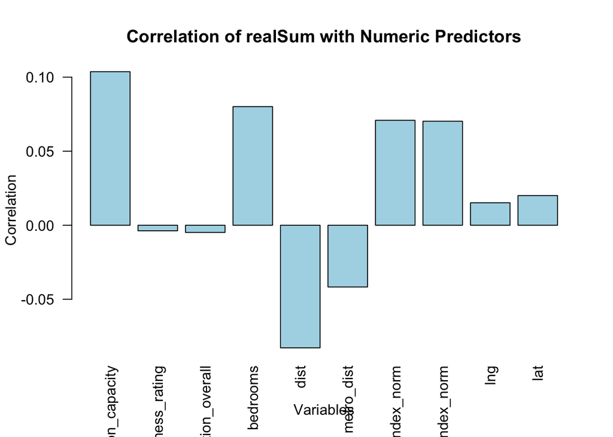

```r
barplot(realSum_cor[-which(names(realSum_cor) == "realSum")],
        main = "Correlation of realSum with Numeric Predictors",
        xlab = "Variables", ylab = "Correlation", col = "lightblue", las = 2)
```

Now we can just eliminate the two irrelevant attributes: cleanliness rating and satisfaction overall

```r
airbnb <- airbnb[,-c(7,8)]
str(airbnb)
```

```
## 'data.frame':    3537 obs. of  14 variables:
##  $ realSum          : num  251 157 283 302 151 ...
##  $ room_type        : Factor w/ 3 levels "Entire home/apt",..: 1 1 1 1 1 2 1 2 1 1 ...
##  $ person_capacity  : int  3 3 5 4 2 2 3 2 4 2 ...
##  $ host_is_superhost: Factor w/ 2 levels "0","1": 2 1 2 2 2 2 2 1 2 2 ...
##  $ multi            : Factor w/ 2 levels "0","1": 2 1 1 1 1 2 1 1 1 2 ...
##  $ biz              : Factor w/ 2 levels "0","1": 1 1 2 2 2 1 2 1 2 1 ...
##  $ bedrooms         : int  1 1 2 2 1 1 1 1 1 1 ...
##  $ dist             : num  1.73 4.81 2.81 3.24 2.24 ...
##  $ metro_dist       : num  0.213 0.228 0.244 0.61 1.12 ...
##  $ attr_index_norm  : num  8.5 5.74 7.25 6.62 8.9 ...
##  $ rest_index_norm  : num  4.42 2.05 3.62 3.1 3.69 ...
##  $ lng              : num  16.4 16.3 16.3 16.3 16.4 ...
##  $ lat              : num  48.2 48.2 48.2 48.2 48.2 ...
##  $ weekend          : Factor w/ 2 levels "0","1": 1 1 1 1 1 1 1 1 1 1 ...
```

Based on the output, we can conclude that the variables that seem to be related to realSum are person_capacity, bedrooms, dist, metro_dist, attr_index_norm, rest_index_norm, lng, and lat.

## 3. Task

In this task we are going to fit a linear regression model with all predictors and display the summary of the model to identify significant variables:

```r
lm_model <- lm(realSum ~ ., data = airbnb)
summary(lm_model)
```

```
##
## Call:
## lm(formula = realSum ~ ., data = airbnb)
##
## Residuals:
##     Min      1Q  Median      3Q     Max
##  -198.7   -62.5   -25.7    18.8 13456.7
##
## Coefficients:
##                         Estimate Std. Error t value Pr(>|t|)
## (Intercept)           -1.203e+04  1.629e+04  -0.739  0.46006
## room_typePrivate room -2.404e+01  1.797e+01  -1.338  0.18108
## room_typeShared room  -9.592e+01  9.914e+01  -0.968  0.33335
## person_capacity        1.922e+01  6.766e+00   2.840  0.00454 **
## host_is_superhost1    -1.186e+01  1.481e+01  -0.801  0.42318
## multi1                -2.082e+01  1.665e+01  -1.251  0.21115
## biz1                   1.906e+01  1.616e+01   1.180  0.23821
## bedrooms               3.523e+01  1.317e+01   2.675  0.00750 **
## dist                  -1.216e+01  5.146e+00  -2.364  0.01815 *
## metro_dist             2.750e+00  1.612e+01   0.171  0.86458
## attr_index_norm        1.805e+00  2.308e+00   0.782  0.43435
## rest_index_norm        1.374e+00  3.838e+00   0.358  0.72036
## lng                    7.632e+01  1.882e+02   0.406  0.68510
## lat                    2.271e+02  3.463e+02   0.656  0.51208
## weekend1               7.984e-01  1.326e+01   0.060  0.95201
## ---
## Signif. codes:  0 '***' 0.001 '**' 0.01 '*' 0.05 '.' 0.1 ' ' 1
##
## Residual standard error: 394 on 3522 degrees of freedom
## Multiple R-squared:  0.02274,    Adjusted R-squared:  0.01886
## F-statistic: 5.854 on 14 and 3522 DF,  p-value: 1.724e-11
```

We conclude that based on the regression analysis, the variables that have a significant (p-value < 0.05) impact on the price are person_capacity, bedrooms and dist

The variance in the price is not explained well through this model because of the low R-squared value.

## 4. Task

In this task we perform a stepwise variable selection by using a backward search:

```r
stepwise_model <- step(lm_model, direction = "backward")
```

```
## Start:  AIC=42291.3
## realSum ~ room_type + person_capacity + host_is_superhost + multi +
##     biz + bedrooms + dist + metro_dist + attr_index_norm + rest_index_norm +
##     lng + lat + weekend
##
##                     Df Sum of Sq       RSS   AIC
## - weekend            1       562 546683875 42289
## - metro_dist         1      4515 546687828 42289
## - rest_index_norm    1     19894 546703207 42289
## - lng                1     25528 546708841 42289
## - lat                1     66728 546750040 42290
## - attr_index_norm    1     94887 546778200 42290
## - room_type          2    404761 547088074 42290
## - host_is_superhost  1     99591 546782904 42290
## - biz                1    216011 546899324 42291
## - multi              1    242777 546926090 42291
## <none>                           546683313 42291
## - dist               1    867220 547550532 42295
## - bedrooms           1   1110796 547794109 42296
## - person_capacity    1   1251890 547935203 42297
##
## Step:  AIC=42289.3
## realSum ~ room_type + person_capacity + host_is_superhost + multi +
##     biz + bedrooms + dist + metro_dist + attr_index_norm + rest_index_norm +
##     lng + lat
##
##                     Df Sum of Sq       RSS   AIC
## - metro_dist         1      4460 546688335 42287
## - rest_index_norm    1     19989 546703864 42287
## - lng                1     25709 546709584 42287
## - lat                1     66616 546750491 42288
## - attr_index_norm    1     94674 546778549 42288
## - room_type          2    404583 547088458 42288
## - host_is_superhost  1     99934 546783809 42288
## - biz                1    216044 546899919 42289
## - multi              1    242891 546926766 42289
## <none>                           546683875 42289
## - dist               1    867054 547550929 42293
## - bedrooms           1   1110875 547794750 42294
## - person_capacity    1   1252722 547936597 42295
```

[output cut: 89 more lines]

```
## - attr_index_norm  1    499098 547848739 42281
## - bedrooms         1   1017852 548367493 42284
## - dist             1   1446106 548795747 42287
## - person_capacity  1   2080129 549429770 42291
##
## Step:  AIC=42279.29
## realSum ~ person_capacity + multi + bedrooms + dist + attr_index_norm
##
##                   Df Sum of Sq       RSS   AIC
## <none>                         547609762 42279
## - attr_index_norm  1    500337 548110099 42281
## - multi            1    700608 548310370 42282
## - bedrooms         1    882744 548492506 42283
## - dist             1   1479973 549089735 42287
## - person_capacity  1   2565968 550175730 42294
```

```r
summary(stepwise_model)
```

```
##
## Call:
## lm(formula = realSum ~ person_capacity + multi + bedrooms + dist +
##     attr_index_norm, data = airbnb)
##
## Residuals:
##     Min      1Q  Median      3Q     Max
##  -218.3   -62.4   -25.7    21.8 13437.3
##
## Coefficients:
##                 Estimate Std. Error t value Pr(>|t|)
## (Intercept)      155.098     29.462   5.264 1.49e-07 ***
## person_capacity   24.472      6.016   4.068 4.85e-05 ***
## multi1           -31.423     14.784  -2.125  0.03362 *
## bedrooms          30.597     12.825   2.386  0.01710 *
## dist             -13.096      4.239  -3.089  0.00202 **
## attr_index_norm    2.357      1.312   1.796  0.07255 .
## ---
## Signif. codes:  0 '***' 0.001 '**' 0.01 '*' 0.05 '.' 0.1 ' ' 1
##
## Residual standard error: 393.8 on 3531 degrees of freedom
## Multiple R-squared:  0.02109,    Adjusted R-squared:  0.0197
## F-statistic: 15.21 on 5 and 3531 DF,  p-value: 8.127e-15
```

#### Conclusion of Task 4:

Looking at the summary we can see the negative/positive impact of each variable on the price(realSum):

**person_capacity:** positive impact -> for each additional person that can stay, the price increases by approx. EUR 24,47 This meets the expectation, because larger accommodations usually charge more to serve more guests

**multi1:** negative impact -> each multi-listing host lowers the price by approx. EUR 31.42 This does not meet the expectation, because you would think that experienced hosts might charge more

**bedrooms:** positive -> each additional bedroom increases the price by approx. EUR 30.60 Yes, one can expect that more bedrooms can mean an increase in the price, since it offers more capacity and comfort

**dist:** negative -> each extra unit of distance from the city center, decreases the price by approx. EUR 13.10 This is what we expected intuitively, since guests usually prefer to stay near touristic attractions and central areas.

**attr_index_norm:** positive -> a one-unit increase in the normalized attraction index will increase the price by approx. EUR 2.3 This is as expected, since accommodations near touristic attractions tend to have higher prices

#### Interpretation of room_type, dist and weekend:

**room_type** and **weekend** are not included in the final model, meaning that they do not significantly impact the price. On the other hand **dist** has a significant negative impact on the price, confirming the intuition that accommodations far away from the city center are lower in price

## 5. Task

In this task we perform an in-sample comparison of model 1 and model 2. Model 1 is the initial linear regression model with all predictors:

```r
lm_model_1 <- lm(realSum ~ ., data = airbnb)
```

Model 2 is the final model after stepwise selection:

```r
lm_model_2 <- stepwise_model
```

Now we start with the In-sample comparison for Model 1:

```r
predicted_values_model_1 <- predict(lm_model_1)

SS_total_model_1 <- sum((airbnb$realSum - mean(airbnb$realSum))^2)
SS_residual_model_1 <- sum((airbnb$realSum - predicted_values_model_1)^2)
R_squared_model_1 <- 1 - (SS_residual_model_1 / SS_total_model_1)

AIC_model_1 <- AIC(lm_model_1)

BIC_model_1 <- BIC(lm_model_1)
```

In-sample comparison for Model 2:

```r
predicted_values_model_2 <- predict(lm_model_2)

SS_total_model_2 <- sum((airbnb$realSum - mean(airbnb$realSum))^2)
SS_residual_model_2 <- sum((airbnb$realSum - predicted_values_model_2)^2)
R_squared_model_2 <- 1 - (SS_residual_model_2 / SS_total_model_2)

AIC_model_2 <- AIC(lm_model_2)

BIC_model_2 <- BIC(lm_model_2)
```

Finally, we can print the results for both models:

```r
cat("\nIn-Sample Comparison:\n")
```

```
##
## In-Sample Comparison:
```

```r
cat("Model 1 - Initial Linear Model:\n")
```

```
## Model 1 - Initial Linear Model:
```

```r
cat("R-squared:", R_squared_model_1, "\n\n")
```

```
## R-squared: 0.02274168
```

```r
cat("AIC:", AIC_model_1, "\n")
```

```
## AIC: 52330.87
```

```r
cat("BIC:", BIC_model_1, "\n\n")
```

```
## BIC: 52429.61
```

```r
cat("Model 2 - Stepwise Selection Model:\n")
```

```
## Model 2 - Stepwise Selection Model:
```

```r
cat("R-squared:", R_squared_model_2, "\n")
```

```
## R-squared: 0.02108555
```

```r
cat("AIC:", AIC_model_2, "\n")
```

```
## AIC: 52318.86
```

```r
cat("BIC:", BIC_model_2, "\n")
```

```
## BIC: 52362.06
```

Model 2 is better because it has a lower AIC and a much lower BIC, meaning it is less complex and fits the data better (good accuracy) . Even though Model 1 has a slightly higher R-squared,meaning that the model is explaining better the differences in our data, it is still not enough to make up for how much more efficient and simple Model 2 is.

## 6. Task

```r
# Set a seed for reproducibility
set.seed(123)

# Create a training index using a random sample of row indices (80% of data)
train_index <- sample(1:nrow(airbnb), size = 0.8 * nrow(airbnb), replace = FALSE)

# Split the data into training and testing sets
train_data <- airbnb[train_index, ]
test_data <- airbnb[-train_index, ]

# Fit full model on the training data
lm_trainFull <- lm(realSum ~ ., data = train_data)


summary(lm_trainFull)
```

```
##
## Call:
## lm(formula = realSum ~ ., data = train_data)
##
## Residuals:
##     Min      1Q  Median      3Q     Max
##  -200.8   -67.5   -29.0    18.0 13440.3
##
## Coefficients:
##                         Estimate Std. Error t value Pr(>|t|)
## (Intercept)           -11790.656  20270.034  -0.582   0.5608
## room_typePrivate room    -15.787     22.204  -0.711   0.4772
## room_typeShared room     -82.929    122.533  -0.677   0.4986
## person_capacity           18.871      8.446   2.234   0.0255 *
## host_is_superhost1       -15.507     18.458  -0.840   0.4009
## multi1                   -26.092     20.799  -1.255   0.2098
## biz1                      18.005     20.131   0.894   0.3712
## bedrooms                  35.425     16.372   2.164   0.0306 *
## dist                     -13.805      6.505  -2.122   0.0339 *
## metro_dist                 7.582     20.152   0.376   0.7068
## attr_index_norm            1.705      3.123   0.546   0.5851
## rest_index_norm            2.014      5.513   0.365   0.7149
## lng                       48.035    232.389   0.207   0.8363
## lat                      231.801    430.715   0.538   0.5905
## weekend1                  -1.332     16.546  -0.081   0.9358
## ---
## Signif. codes:  0 '***' 0.001 '**' 0.01 '*' 0.05 '.' 0.1 ' ' 1
##
## Residual standard error: 438.9 on 2814 degrees of freedom
## Multiple R-squared:  0.01836,    Adjusted R-squared:  0.01347
## F-statistic: 3.759 on 14 and 2814 DF,  p-value: 2.553e-06
```

```r
# Perform stepwise selection on the full model
stepwise_train <- step(lm_trainFull, direction = "backward")
```

```
## Start:  AIC=34439.24
## realSum ~ room_type + person_capacity + host_is_superhost + multi +
##     biz + bedrooms + dist + metro_dist + attr_index_norm + rest_index_norm +
##     lng + lat + weekend
##
##                     Df Sum of Sq       RSS   AIC
## - room_type          2    177048 542146246 34436
## - weekend            1      1249 541970447 34437
## - lng                1      8229 541977426 34437
## - rest_index_norm    1     25711 541994908 34437
## - metro_dist         1     27264 541996461 34437
## - lat                1     55783 542024981 34438
## - attr_index_norm    1     57429 542026626 34438
## - host_is_superhost  1    135934 542105131 34438
## - biz                1    154074 542123272 34438
## - multi              1    303105 542272302 34439
## <none>                           541969197 34439
## - dist               1    867541 542836739 34442
## - bedrooms           1    901677 542870875 34442
## - person_capacity    1    961420 542930618 34442
##
## Step:  AIC=34436.17
## realSum ~ person_capacity + host_is_superhost + multi + biz +
##     bedrooms + dist + metro_dist + attr_index_norm + rest_index_norm +
##     lng + lat + weekend
##
##                     Df Sum of Sq       RSS   AIC
## - weekend            1      1779 542148024 34434
## - lng                1      8434 542154680 34434
## - rest_index_norm    1     28213 542174459 34434
## - metro_dist         1     38926 542185171 34434
## - attr_index_norm    1     53713 542199959 34434
## - lat                1     58864 542205109 34434
## - host_is_superhost  1    124219 542270465 34435
## - biz                1    162515 542308760 34435
## - multi              1    323596 542469842 34436
## <none>                           542146246 34436
## - bedrooms           1    839518 542985764 34439
## - dist               1    938369 543084615 34439
## - person_capacity    1   1453807 543600052 34442
```

[output cut: 90 more lines]

```
## - attr_index_norm  1    404108 542854162 34426
## - bedrooms         1    885079 543335133 34428
## - dist             1   1279202 543729256 34430
## - person_capacity  1   1400134 543850188 34431
##
## Step:  AIC=34424.63
## realSum ~ person_capacity + multi + bedrooms + dist + attr_index_norm
##
##                   Df Sum of Sq       RSS   AIC
## <none>                         542618905 34425
## - attr_index_norm  1    407749 543026654 34425
## - multi            1    722581 543341485 34426
## - bedrooms         1    780433 543399338 34427
## - dist             1   1298398 543917303 34429
## - person_capacity  1   1747491 544366396 34432
```

```r
# Display the summary of the stepwise model
summary(stepwise_train)
```

```
##
## Call:
## lm(formula = realSum ~ person_capacity + multi + bedrooms + dist +
##     attr_index_norm, data = train_data)
##
## Residuals:
##     Min      1Q  Median      3Q     Max
##  -219.2   -66.7   -28.1    19.2 13429.1
##
## Coefficients:
##                 Estimate Std. Error t value Pr(>|t|)
## (Intercept)      165.805     37.574   4.413 1.06e-05 ***
## person_capacity   22.625      7.504   3.015  0.00259 **
## multi1           -35.817     18.473  -1.939  0.05262 .
## bedrooms          32.092     15.927   2.015  0.04400 *
## dist             -13.885      5.343  -2.599  0.00940 **
## attr_index_norm    2.515      1.727   1.456  0.14537
## ---
## Signif. codes:  0 '***' 0.001 '**' 0.01 '*' 0.05 '.' 0.1 ' ' 1
##
## Residual standard error: 438.4 on 2823 degrees of freedom
## Multiple R-squared:  0.01718,    Adjusted R-squared:  0.01544
## F-statistic:  9.87 on 5 and 2823 DF,  p-value: 2.274e-09
```

```r
# Make predictions using the full model
pred_full_train <- predict(lm_trainFull, newdata = train_data)
pred_full_test <- predict(lm_trainFull, newdata = test_data)

# Make predictions using the stepwise model
pred_step_train <- predict(stepwise_train, newdata = train_data)
pred_step_test <- predict(stepwise_train, newdata = test_data)

# Calculate the MSE for the full model
mse_full_train <- mean((train_data$realSum - pred_full_train)^2)
mse_full_test <- mean((test_data$realSum - pred_full_test)^2)

# Calculate the MSE for the stepwise model
mse_step_train <- mean((train_data$realSum - pred_step_train)^2)
mse_step_test <- mean((test_data$realSum - pred_step_test)^2)

# Print the MSE values
cat("Full Model - Training MSE: ", mse_full_train, "\n")
```

```
## Full Model - Training MSE:  191576.2
```

```r
cat("Full Model - Test MSE: ", mse_full_test, "\n")
```

```
## Full Model - Test MSE:  6900.676
```

```r
cat("Stepwise Model - Training MSE: ", mse_step_train, "\n")
```

```
## Stepwise Model - Training MSE:  191805.9
```

```r
cat("Stepwise Model - Test MSE: ", mse_step_test, "\n")
```

```
## Stepwise Model - Test MSE:  7185.729
```

Following variables were omitted: room_type, weekend, lng, rest_index_norm, metro_dist, lat, host_is_superhost, biz The final stepwise model includes the following variables: person_capacity, multi + bedrooms, dist, attr_index_norm

According to the theory the stepwsie model should have a larger training MSE, because it is the more simpler model. Simpler models have high bias, that means that they do not capture all patterns in the data and have a low variance, which means that if we change slightly the data the results won’t change dramatically.

The initial model, which is a more complex model usually has a higher test MSE and is more likely to overfit and learn from the noise. A higher test MSE means that the model performs worse on unseen data.

In our case the initial model performs slightly better on the training MSE (0,12% less than the more complex model), which is expected because it includes more predictors.

Surprisingly the initial model also has a lower test MSE in our case, but it is important to note that the difference again is not substantial (4,13% less).

Since both models perform very similar on training and test MSE, we choose the stepwise model since it is a more simpler model and is less likely to overfit and learn from the noise.